# IODS course project

### Describe and interpret the outputs, commenting on the distributions of the variables and the relationships between them.

```
##  gender       age           attitude          deep            stra
##  F:110   Min.   :17.00   Min.   :1.400   Min.   :1.583   Min.   :1.250
##  M: 56   1st Qu.:21.00   1st Qu.:2.600   1st Qu.:3.333   1st Qu.:2.625
##          Median :22.00   Median :3.200   Median :3.667   Median :3.188
##          Mean   :25.51   Mean   :3.143   Mean   :3.680   Mean   :3.121
##          3rd Qu.:27.00   3rd Qu.:3.700   3rd Qu.:4.083   3rd Qu.:3.625
##          Max.   :55.00   Max.   :5.000   Max.   :4.917   Max.   :5.000
##       surf           points
##  Min.   :1.583   Min.   : 7.00
##  1st Qu.:2.417   1st Qu.:19.00
##  Median :2.833   Median :23.00
##  Mean   :2.787   Mean   :22.72
##  3rd Qu.:3.167   3rd Qu.:27.75
##  Max.   :4.333   Max.   :33.00
```

- The male and female participants were 56 and 110 resp. The minumum and maximum age of the participants were 17 and 55 resp. The mean age was 25.51.
- The attitude variable had minimum and maximum values 1.40 and 5.00 resp. Considering 5-point scale (Likert Scale), the mean attitude showed neutral response with value 3.14.
- The deep, strategic and surface learning had mean values 3.68, 3.12, 2.78 resp. The deep learning had slightly high mean than the strategic learning. Therefore, the deep learning was the prevailing learning approach as compared to strategic and surface ones.
- Regarding exam points, the maximum and minimum points were 33 and 7 resp. The mean points were 22.7.

### Choose three variables as explanatory variables and fit a regression model where exam points is the target (dependent) variable. Show a summary of the fitted model and comment and interpret the results.

```
##
## Call:
## lm(formula = points ~ attitude + surf + stra, data = new_data)
##
## Residuals:
##      Min       1Q   Median       3Q      Max
## -17.1550  -3.4346   0.5156   3.6401  10.8952
##
## Coefficients:
##             Estimate Std. Error t value Pr(>|t|)
## (Intercept)  11.0171     3.6837   2.991  0.00322 **
## attitude      3.3952     0.5741   5.913 1.93e-08 ***
## surf         -0.5861     0.8014  -0.731  0.46563
## stra          0.8531     0.5416   1.575  0.11716
## ---
## Signif. codes:  0 '***' 0.001 '**' 0.01 '*' 0.05 '.' 0.1 ' ' 1
##
## Residual standard error: 5.296 on 162 degrees of freedom
## Multiple R-squared:  0.2074, Adjusted R-squared:  0.1927
## F-statistic: 14.13 on 3 and 162 DF,  p-value: 3.156e-08
```

```
##               Estimate Std. Error    t value     Pr(>|t|)
## (Intercept) 11.0171133  3.6837473  2.9907353 3.217932e-03
## attitude     3.3952206  0.5741484  5.9134895 1.926549e-08
## surf        -0.5860735  0.8013813 -0.7313291 4.656347e-01
## stra         0.8531325  0.5415940  1.5752250 1.171554e-01
```

- The three variables selected for regression analysis were attitude, surface learning and strategic learning. The regression output showed that the strategic and surface learning were not statistically significant. On the other hand, attitude seemed to be statistically significant as its value is less than the p-significance level (0.05). Taken into consideration the coefficient p-values and to increase the model precision, strategic and surface learning will be excluded in the final model.

### If an explanatory variable in your model does not have a statistically significant relationship with the target variable, remove the variable from the model and fit the model again without it

```
##
## Call:
## lm(formula = points ~ attitude, data = new_data)
##
## Residuals:
##      Min       1Q   Median       3Q      Max
## -16.9763  -3.2119   0.4339   4.1534  10.6645
##
## Coefficients:
##             Estimate Std. Error t value Pr(>|t|)
## (Intercept)  11.6372     1.8303   6.358 1.95e-09 ***
## attitude      3.5255     0.5674   6.214 4.12e-09 ***
## ---
## Signif. codes:  0 '***' 0.001 '**' 0.01 '*' 0.05 '.' 0.1 ' ' 1
##
## Residual standard error: 5.32 on 164 degrees of freedom
## Multiple R-squared:  0.1906, Adjusted R-squared:  0.1856
## F-statistic: 38.61 on 1 and 164 DF,  p-value: 4.119e-09
```

### Produce the following diagnostic plots: Residuals vs Fitted values, Normal QQ-plot and Residuals vs Leverage.

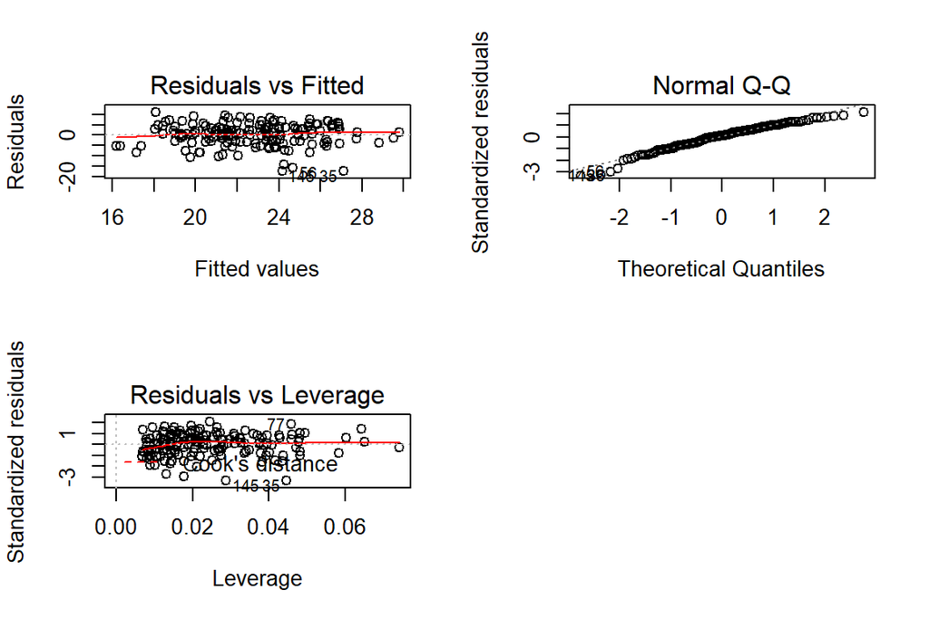

### Explain the assumptions of the model and interpret the validity of those assumptions based on the diagnostic plots.

- Residual vs Fitted plot:

  ```
      This plot is used to determine non-linearity. The plot seemed OK.The data appeared to be randomly spread around the straight line except for some points (35,56 and 145). The straight line showed no non-linear trend to the residuals.
  ```

- Normal Q-Q

  ```
      This plot is used to determine whether the residuals are normally distributed or not. The residuals in this plot were slightly deviated from the diagonal line in both the upper and lower tail. Points 35, 145 and 56 looked a little off here. The residuals were approximately normally distributed.
  ```

- Residuals vs Leverage

  ```
      This plot is used to find influential cases. The plot seemed to have no influential cases. The Cook's distance line/dashed curves did not appear on the plot.
  ```

### References

- https://campus.datacamp.com/courses/helsinki-open-data-science/regression-and-model-validation?ex=1
- http://www.helsinki.fi/~kvehkala/JYTmooc/JYTOPKYS3-meta.txt
- http://statisticsbyjim.com/regression/standard-error-regression-vs-r-squared/

# Student performance including alcohol consumption

### **1. Introduction**:

- The data used in analysis was based on student achievement in secondary education of two Portuguese schools. Student grades, demographic, social and school related features were collected by using school reports and questionnaires.Two datasets were provided to see the performance in Mathematics and Portuguese language. The Mathematics and Portuguese core classes were modeled using binary/five-level classification and regression tasks.

```
## [1] 382  35
```

```
##  [1] "school"     "sex"        "age"        "address"    "famsize"
##  [6] "Pstatus"    "Medu"       "Fedu"       "Mjob"       "Fjob"
## [11] "reason"     "nursery"    "internet"   "guardian"   "traveltime"
## [16] "studytime"  "failures"   "schoolsup"  "famsup"     "paid"
## [21] "activities" "higher"     "romantic"   "famrel"     "freetime"
## [26] "goout"      "Dalc"       "Walc"       "health"     "absences"
## [31] "G1"         "G2"         "G3"         "alc_use"    "high_use"
```

- It has 382 observations of 35 variables. The more detailed description of data attributes for both math and portuguese language course can be found at https://archive.ics.uci.edu/ml/datasets/Student+Performance.
- The two variables alc_use and high_use were added in the the dataset. Alc_use was made using the average of ‘Dalc’ and ‘Walc’. ‘Dalc’ and ‘Walc’ numerical attributes were referred to workday and weekend alcohol consumption (1 - very low to 5 - very high). Attribute high_use was true if alc_use is greater than 2 and false otherwise.